# Cell division topological specificity factor

Fold-switch pair **3r9jC_2kxoA** — **3r9jC** vs **2kxoA**

Escherichia coli K-12 / Neisseria gonorrhoeae

## Figure 1: Phylogenetic tree with per-cluster fold-preference heatmap.

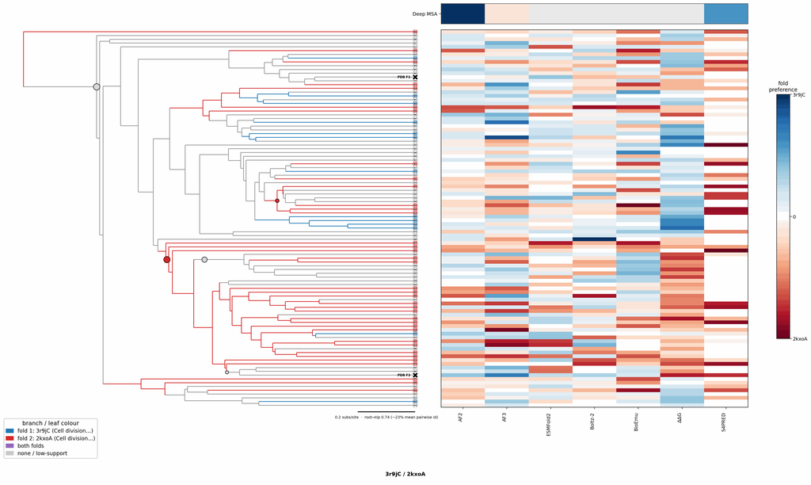

## Figure 2: Aligned overlay (both folds superposed)

The single fold-switching chain of each fold superposed by TM-align; waters hidden, any ligand shown as green sticks. Grey = structurally conserved core, colour = divergent (fold-switching) region.

3r9jC (Cell division topological specificity factor) · dimer2kxoA (Cell division topological specificity factor) · monomerLigand ADP (bound to 3r9jC)

TM-score: 0.420 · Trigger class: mutation

Aligned overlay

## Figure 3: The two folds, side by side

Each fold is coloured by per-residue Cα deviation between the two superposed structures: grey ≈ conserved core, full colour = structurally divergent (fold-switching) region.

3r9jC (Cell division topological specificity factor)

2kxoA (Cell division topological specificity factor)

0 Å5≥10 Å

3r9jC (Cell division topological specificity factor)

2kxoA (Cell division topological specificity factor)

## Figure 4: Best-cluster predicted contact maps over the two true folds.

Predicted contact maps (MSA-Transformer) for the clusters best matching each fold, over the true contacts of fold 1 (upper triangle) and fold 2 (lower). Divergent contacts between clusters are the contact-level signature of fold-switching.

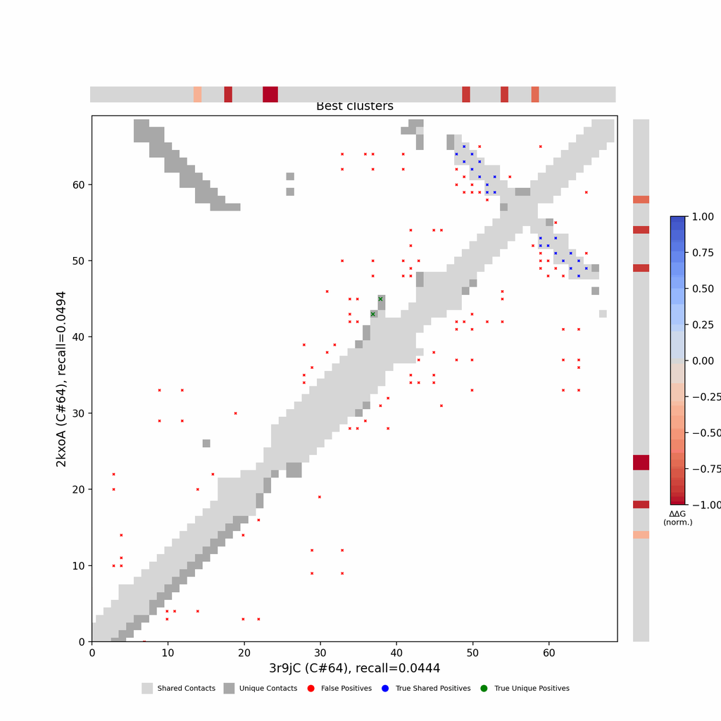

## Figure 5: Per-residue ΔΔG fold-preference contribution

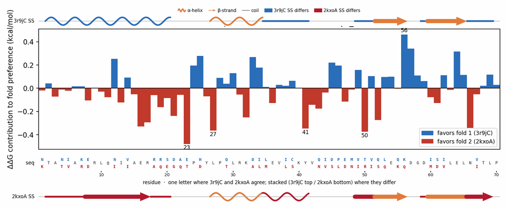

**More figures**

## Figure 6: Deep-MSA contact map panel / Best clusters contact map panel

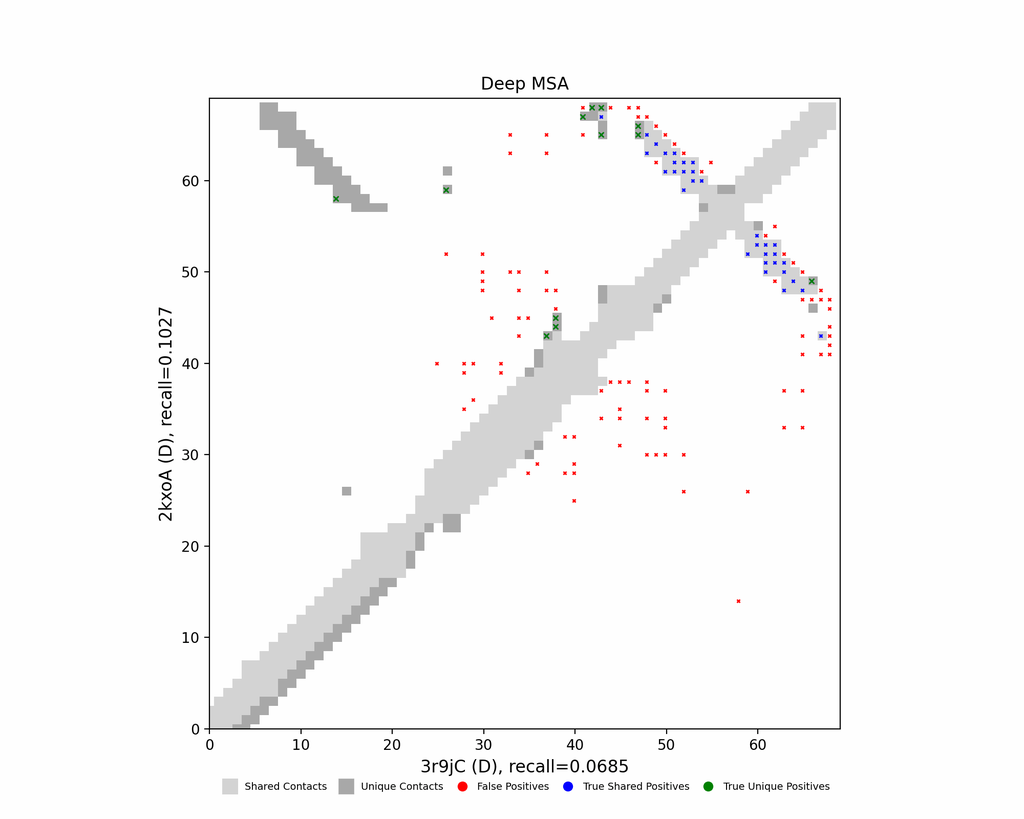

Deep-MSA contact map panel

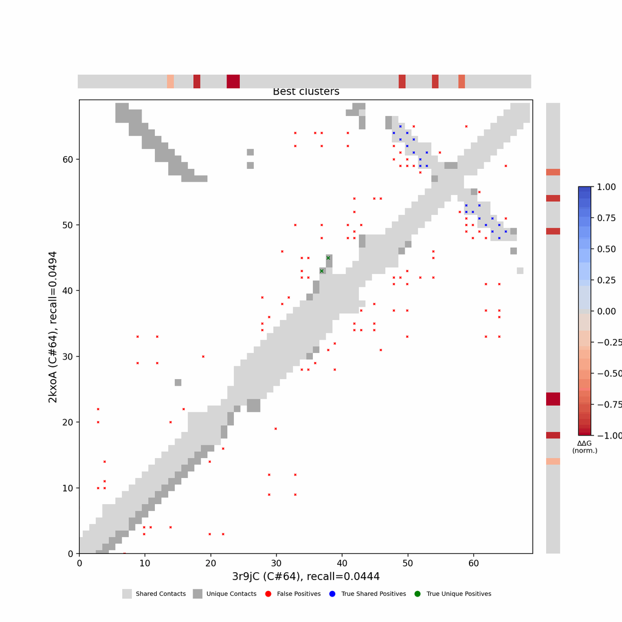

Best clusters contact map panel

## Figure 7: All clusters contact-map mosaic (small multiples).

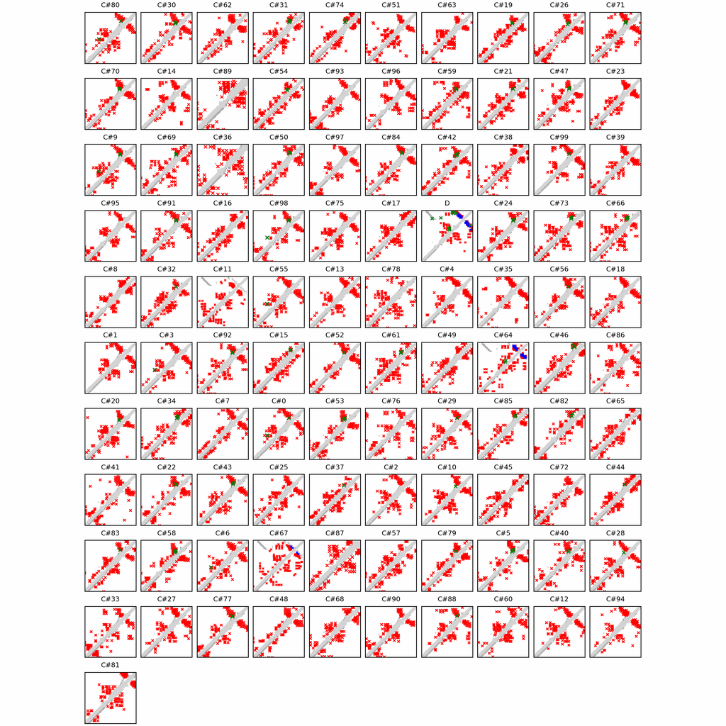

## Figure 8: Phylo null: tree with shuffled cluster fold labels.

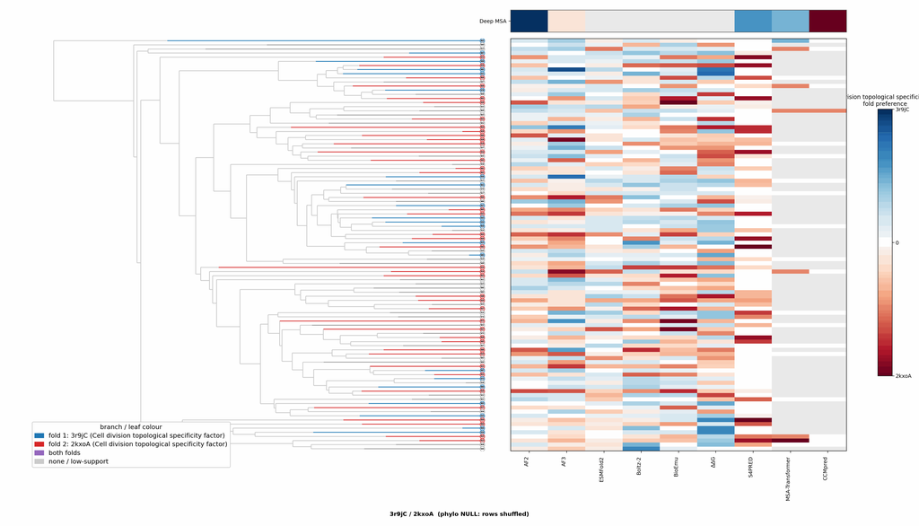

## Cluster metrics table

Per-cluster metrics underlying the figures above.

| cluster | n | neff | AF2_TM1 | AF2_TM2 | AF3_TM1 | AF3_TM2 | RE-MSAT-COM | RE-MSAT1 | RE-MSAT2 | ESM_SEQIDS | ESM_TM1 | ESM_TM2 | ΔΔG_Bias | ΔΔG_Bias_std | ΔΔG_frac_F1 | Boltz2_pref | S4PRED_pref | CCMpred_pref | BioEmu_pref |
| --- | --- | --- | --- | --- | --- | --- | --- | --- | --- | --- | --- | --- | --- | --- | --- | --- | --- | --- | --- |
| Deep | - | - | 0.7 | 0.39 | 0.54 | 0.56 | 0.37 | 0.42 | 0.26 | - | - | - | - | - | - | - | 0.17 | -0.02 | - |
| 000 | 779.0 | 229.0 | 0.35 | 0.28 | 0.47 | 0.45 | 0.0 | 0.0 | 0.16 | 004; 004; 006; 006; 007; 007; 001; 001; 003; 003 | 0.59 ± 0.03 | 0.38 ± 0.05 | 1.23 | 2.64 | 0.7 | -0.03 | 0.17 | -0.01 | 0.05 |
| 001 | 708.0 | 322.0 | 0.42 | 0.34 | 0.51 | 0.49 | 0.0 | 0.0 | 0.0 | 004; 004; 003; 003; 001; 006; 001; 006; 002; 002 | 0.57 ± 0.02 | 0.36 ± 0.03 | -0.15 | 1.14 | 0.4 | 0.01 | -0.0 | 0.0 | 0.03 |
| 002 | 665.0 | 241.0 | 0.41 | 0.37 | 0.42 | 0.37 | 0.0 | 0.0 | 0.0 | 001; 001; 005; 005; 006; 006; 004; 004; 007; 007 | 0.58 ± 0.02 | 0.42 ± 0.08 | 0.86 | 2.08 | 0.6 | 0.04 | 0.18 | 0.0 | 0.02 |
| 003 | 581.0 | 339.0 | 0.45 | 0.43 | 0.51 | 0.51 | 0.0 | 0.0 | 0.0 | 002; 002; 003; 003; 006; 005; 006; 005; 001; 001 | 0.59 ± 0.04 | 0.39 ± 0.01 | 1.75 | 2.37 | 0.7 | 0.03 | 0.08 | 0.0 | 0.03 |
| 004 | 430.0 | 196.0 | 0.36 | 0.32 | 0.33 | 0.31 | 0.0 | 0.0 | 0.0 | 004; 004; 007; 007; 001; 001; 006; 009; 006; 008 | 0.55 ± 0.04 | 0.41 ± 0.07 | 2.24 | 1.64 | 0.8 | -0.02 | 0.17 | 0.0 | 0.02 |
| 005 | 402.0 | 78.0 | 0.46 | 0.4 | 0.33 | 0.26 | 0.0 | 0.0 | 0.0 | 006; 006; 007; 007; 002; 003; 002; 003; 004; 004 | 0.57 ± 0.04 | 0.34 ± 0.02 | -1.57 | 0.67 | 0.0 | -0.01 | 0.14 | 0.0 | 0.04 |
| 006 | 311.0 | 149.0 | 0.43 | 0.53 | 0.5 | 0.51 | 0.0 | 0.0 | 0.0 | 006; 004; 004; 006; 005; 005; 007; 007; 002; 002 | 0.57 ± 0.04 | 0.35 ± 0.01 | 1.96 | 1.26 | 0.9 | -0.07 | -0.02 | 0.0 | -0.03 |
| 007 | 276.0 | 32.0 | 0.39 | 0.4 | 0.37 | 0.39 | 0.0 | 0.0 | 0.0 | 002; 003; 003; 002; 001; 001; 006; 006; 004; 004 | 0.54 ± 0.04 | 0.41 ± 0.05 | 1.3 | 3.24 | 0.6 | -0.07 | 0.17 | 0.0 | 0.0 |
| 008 | 275.0 | 92.0 | 0.42 | 0.38 | 0.46 | 0.48 | 0.0 | 0.0 | 0.0 | 006; 006; 007; 007; 001; 001; 008; 008; 005; 005 | 0.60 ± 0.04 | 0.34 ± 0.01 | 2.47 | 1.32 | 0.9 | -0.07 | 0.06 | 0.0 | 0.02 |
| 009 | 220.0 | 116.0 | 0.48 | 0.5 | 0.46 | 0.48 | 0.0 | 0.0 | 0.09 | 005; 005; 003; 003; 008; 008; 002; 002; 001; 001 | 0.56 ± 0.04 | 0.40 ± 0.08 | 1.0 | 1.62 | 0.7 | -0.03 | 0.11 | 0.0 | -0.0 |
| 010 | 216.0 | 55.0 | 0.47 | 0.61 | 0.41 | 0.54 | 0.0 | 0.0 | 0.0 | 008; 008; 005; 005; 003; 004; 006; 006; 003; 004 | 0.56 ± 0.02 | 0.37 ± 0.01 | -0.46 | 0.85 | 0.3 | -0.06 | 0.17 | 0.0 | 0.01 |
| 011 | 212.0 | 63.0 | 0.29 | 0.38 | 0.38 | 0.4 | 0.0 | 0.0 | 0.0 | 002; 002; 004; 004; 005; 005; 003; 003; 001; 001 | 0.54 ± 0.06 | 0.43 ± 0.03 | 2.28 | 1.28 | 0.9 | -0.03 | 0.08 | 0.0 | 0.01 |
| 012 | 202.0 | 98.0 | 0.42 | 0.35 | 0.43 | 0.38 | 0.0 | 0.0 | 0.0 | 006; 006; 005; 005; 009; 009; 007; 007; 001; 002 | 0.54 ± 0.02 | 0.43 ± 0.10 | 1.17 | 1.93 | 0.7 | 0.0 | 0.17 | 0.0 | 0.03 |
| 013 | 198.0 | 108.0 | 0.44 | 0.48 | 0.44 | 0.51 | 0.0 | 0.0 | 0.0 | 008; 008; 004; 004; 003; 003; 001; 001; 006; 006 | 0.53 ± 0.04 | 0.39 ± 0.06 | 2.24 | 1.23 | 1.0 | -0.05 | -0.08 | 0.0 | -0.0 |
| 014 | 198.0 | 31.0 | 0.44 | 0.38 | 0.44 | 0.61 | 0.0 | 0.0 | 0.0 | 003; 003; 007; 007; 006; 006; 008; 008; 004; 004 | 0.61 ± 0.05 | 0.38 ± 0.01 | 0.06 | 1.58 | 0.2 | 0.07 | 0.17 | 0.0 | 0.02 |
| 015 | 196.0 | 85.0 | 0.44 | 0.45 | 0.47 | 0.5 | 0.0 | 0.0 | 0.0 | 004; 004; 007; 007; 009; 009; 006; 006; 003; 003 | 0.58 ± 0.04 | 0.37 ± 0.01 | 1.86 | 1.99 | 0.8 | -0.04 | 0.02 | 0.0 | 0.02 |
| 016 | 194.0 | 66.0 | 0.48 | 0.48 | 0.36 | 0.29 | 0.0 | 0.0 | 0.0 | 003; 003; 001; 008; 008; 001; 007; 005; 005; 007 | 0.59 ± 0.02 | 0.36 ± 0.02 | 2.35 | 1.2 | 1.0 | -0.06 | -0.04 | 0.0 | 0.02 |
| 017 | 193.0 | 68.0 | 0.33 | 0.33 | 0.32 | 0.36 | 0.0 | 0.0 | 0.0 | 002; 002; 003; 003; 006; 006; 001; 004; 001; 004 | 0.56 ± 0.06 | 0.45 ± 0.08 | 1.42 | 1.52 | 0.8 | -0.02 | 0.18 | 0.0 | 0.01 |
| 018 | 189.0 | 66.0 | 0.49 | 0.51 | 0.44 | 0.39 | 0.0 | 0.0 | 0.0 | 001; 001; 002; 002; 004; 004; 007; 007; 008; 003 | 0.51 ± 0.07 | 0.31 ± 0.02 | -0.34 | 1.15 | 0.4 | -0.06 | 0.08 | 0.0 | 0.0 |
| 019 | 185.0 | 32.0 | 0.38 | 0.37 | 0.39 | 0.38 | 0.0 | 0.0 | 0.0 | 003; 003; 006; 006; 010; 010; 001; 001; 002; 002 | 0.59 ± 0.04 | 0.39 ± 0.02 | -0.45 | 0.54 | 0.2 | -0.03 | 0.12 | 0.0 | 0.03 |
| 020 | 183.0 | 58.0 | 0.47 | 0.6 | 0.44 | 0.48 | 0.0 | 0.0 | 0.0 | - | - | - | -0.56 | 0.96 | 0.4 | -0.04 | 0.05 | - | -0.01 |
| 021 | 175.0 | 25.0 | 0.46 | 0.57 | 0.46 | 0.6 | 0.0 | 0.0 | 0.0 | - | - | - | 0.02 | 1.89 | 0.4 | -0.07 | 0.17 | - | 0.02 |
| 022 | 165.0 | 33.0 | 0.32 | 0.28 | 0.33 | 0.32 | 0.0 | 0.0 | 0.4 | - | - | - | -1.67 | 0.73 | 0.0 | 0.02 | 0.18 | - | 0.03 |
| 023 | 161.0 | 88.0 | 0.32 | 0.35 | 0.46 | 0.54 | 0.0 | 0.0 | 0.0 | - | - | - | 2.58 | 1.46 | 0.9 | -0.01 | 0.17 | - | 0.01 |
| 024 | 159.0 | 102.0 | 0.44 | 0.48 | 0.43 | 0.45 | 0.0 | 0.0 | 0.0 | - | - | - | 2.21 | 1.3 | 1.0 | -0.05 | 0.09 | - | -0.0 |
| 025 | 158.0 | 29.0 | 0.46 | 0.41 | 0.44 | 0.4 | 0.0 | 0.0 | 0.0 | - | - | - | 0.25 | 1.13 | 0.7 | -0.12 | 0.18 | - | 0.01 |
| 026 | 154.0 | 30.0 | 0.41 | 0.62 | 0.43 | 0.56 | 0.0 | 0.0 | 0.0 | - | - | - | -0.12 | 1.07 | 0.6 | -0.16 | 0.15 | - | -0.02 |
| 027 | 152.0 | 58.0 | 0.49 | 0.57 | 0.49 | 0.58 | 0.0 | 0.0 | 0.0 | - | - | - | -0.39 | 1.79 | 0.4 | -0.06 | 0.17 | - | -0.01 |
| 028 | 149.0 | 34.0 | 0.45 | 0.42 | 0.42 | 0.6 | 0.0 | 0.0 | 0.0 | - | - | - | 0.0 | 0.81 | 0.4 | 0.0 | 0.08 | - | 0.02 |

[output cut: 71 more lines]